# CCS 消融实验：结构可复现性

Bensz Conan

2026-10-07

本报告是 ablation-03 实验的结构可复现性模块；读取双向投影与 matched-bank 分析结果，不运行模型计算。前一份 gene signature 报告检查“同一患者附近的邻居，在连续表达分数上是否足够接近”；本报告把视线拉远，检查**一组生物状态之间的远近次序，换一批独立患者后是否仍然相似**。局部街道的邻居变了，不等于城市主要地标之间的相对位置也被打乱；两种尺度必须分别测量。

这样做与 CCS 的目标相连：d1 由多队列模型构成，如果它要成为有用的跨癌种表示，至少应检查原本能跨队列辨认的生物组织有没有被任意打散。这里的结果仍不是临床效用或等价性试验；它只检验预先定义的五类 gene signature 所形成的状态地图。

## 1 数据概览

reference 与 external bank 分别包含 150 和 43 个模块。正向有效队列对为 903 对；共享 cohort 的队列对并非独立重复。

## 2 关键函数、参数与源代码位置

| 过程 | 函数与参数 | 约定 | 源代码 |
| --- | --- | --- | --- |
| 结构表达输入 | `.asr_extract_anchor_cache()` | 准备阶段固定完整样本范围和 signature | 01.03.00. 生物输入准备.R |
| 生物状态 | `.asr_assign_anchor_states()`；两端各三分之一 | 每实体至少 8 个样本；并列边界不强制分组 | 02.03.00. 结构复现分析_functions.R |
| 双向推断 | `.asr_evaluate_direction()`；cohort-node bootstrap | 保留 reference→external 与 external→reference 的原设计 | 02.03.00. 结构复现分析.R |
| 匹配敏感性 | `.asr_matched_bank_design()`；20 次重复 | 同 tissue、同模块预算；范围不作为置信区间 | 02.03.00. 结构复现分析_functions.R |

## 3 指标导读

| 指标 | 输入与计算 | 尺度、方向及不能推出的结论 |
| --- | --- | --- |
| 结构相似度 | 在同一表示下，对两个 cohort 共有的高低状态计算质心两两距离，再对两份距离排序求 Spearman | −1 至 1；越高表示这组状态的远近次序越可复现，不表示患者逐一相同或绝对距离相等 |
| d1−Direct | 对同一个队列对，用 d1 结构相似度减 Direct 结构相似度 | 零表示当前队列对两臂相同；正值偏向 d1，跨零不证明无信息损失 |
| 95% CI | 达到至少 4 个 cohort、3 个队列对时，以 cohort 节点为单位重采样 | 反映队列节点变动；共享 cohort 的队列对不能当成独立重复 |
| Matched-bank 范围 | 固定目标样本与模块预算，多次更换 tissue 匹配的 bank 组成 | 最小至最大值只表示本次设计敏感性，不是新患者的概率覆盖区间 |

## 4 独立队列间的生物结构可复现性

可以把五类 gene signature 各自的“高”和“低”想成十个地图地标。每个目标 cohort 内分别取 gene signature 分数两端三分之一，形成相对高低状态；因此“乳腺癌队列中的免疫高”和“肺癌队列中的免疫高”都只表示各自队列内较高，不要求两者达到同一绝对表达值。每个状态至少有 8 个样本；常量分数或分位边界并列时不强行切分。Direct 和 d1 各自计算地标的质心距离，再比较不同 cohort 中**地标远近的排序**是否一致。排序越相似，说明这套较粗的生物关系越容易跨队列复现；它不表示患者逐一相同。

计算按样本、状态、队列对逐层进行。第一步，在表示 $m$ 中对 cohort $c$ 的状态 $e$ 所有样本坐标取平均，得到该状态的质心 $\boldsymbol\mu_{c,e}^{(m)}$。第二步，在**同一 cohort、同一表示**中计算两个状态 $e,f$ 的质心欧氏距离 $D_{c,e,f}^{(m)}=\|\boldsymbol\mu_{c,e}^{(m)}-\boldsymbol\mu_{c,f}^{(m)}\|_2$。第三步，取 cohort $a,b$ 共有的状态，分别列出所有不重复状态对的距离；对两列距离的名次求相关，得到 $S_{a,b}^{(m)}=\operatorname{Spearman}(D_a^{(m)},D_b^{(m)})$。例如两个队列都把“免疫高”和“免疫低”排成最远的一对，便会提高排序的一致性；它们相差的绝对距离仍可能不同。最后在**同一个队列对**上相减，$\Delta_{a,b}=S_{a,b}^{(d1)}-S_{a,b}^{(Direct)}$，才是在问换成 d1 后跨队列排序更稳定还是更不稳定。相关接近 1 表示这组状态的远近次序较一致，接近 0 表示没有稳定排序关系；它不证明高低状态的临床定义跨队列相同。

正向使用 reference d1 modules 投影 external targets，反向使用 external d1 modules 投影 reference targets。这样做像用两套不同学校的阅卷经验去看另一侧的答卷，用于检查结论是否过度依赖某一套模型。**反向 Direct 仍沿用正向的冻结特征合同**，只交换尺度拟合侧；所以反向是固定 Direct 基准下的敏感性检查，不能写成两臂所有学习步骤均完全对称地重新外部化。

```r
render_dt(
  structural_directional_summary[, c(
    "direction", "bank_role", "target_role", "scope",
    "bank_module_count", "bank_feature_count", "fit_sample_count",
    "target_sample_count", "cohort_count", "cohort_pair_count",
    "mean_direct_similarity", "mean_d1_similarity", "mean_delta",
    "fraction_d1_ge_direct", "mean_delta_ci_low", "mean_delta_ci_high",
    "inference_status"
  )],
  pageLength = 4L
)
```

|  | direction | bank_role | target_role | scope | bank_module_count | bank_feature_count | fit_sample_count | target_sample_count | cohort_count | cohort_pair_count | mean_direct_similarity | mean_d1_similarity | mean_delta | fraction_d1_ge_direct | mean_delta_ci_low | mean_delta_ci_high | inference_status |
| --- | --- | --- | --- | --- | --- | --- | --- | --- | --- | --- | --- | --- | --- | --- | --- | --- | --- |
| 1 | reference_bank_to_external_targets | reference | external | all_cohort_pairs | 150 | 583 | 24487 | 14060 | 43 | 903 | 0.713317342134329 | 0.700913949548934 | -0.0124033925853946 | 0.440753045404208 | -0.0297496541060566 | 0.00477633620899478 | estimable |
| 2 | reference_bank_to_external_targets | reference | external | same_cancer_type | 150 | 583 | 24487 | 14060 | 26 | 22 | 0.728889687387711 | 0.717828482452988 | -0.0110612049347227 | 0.409090909090909 | -0.0515494764579432 | 0.0284963862224732 | estimable |
| 3 | external_bank_to_reference_targets | external | reference | all_cohort_pairs | 43 | 170 | 14060 | 24487 | 143 | 10153 | 0.579842719992489 | 0.581947761125277 | 0.00210504113278812 | 0.526642371712794 | -0.0168101941103833 | 0.0190013999197414 | estimable |
| 4 | external_bank_to_reference_targets | external | reference | same_cancer_type | 43 | 170 | 14060 | 24487 | 137 | 1375 | 0.610418690643017 | 0.606942172437229 | -0.00347651820578783 | 0.547636363636364 | -0.0363815709503043 | 0.0263001685478361 | estimable |

解读：`bank_role` 标明冻结模块来自哪一侧，`target_role` 标明接受投影的患者来自哪一侧。正向用 150 个 reference 模块，从 24487 个拟合侧样本投影到 14060 个 external target；平均 d1−Direct 结构差为 -0.0124，节点 bootstrap 区间为 [-0.0297, 0.0048]。反向用 43 个 external 模块，目标侧改为 24487 个 reference 样本；平均差为 0.0021，区间为 [-0.0168, 0.0190]。两方向都只见小幅平均差，但 bank 数量、目标人群同时改变，反向还沿用正向冻结的 Direct 特征合同；它们是投影方向敏感性检查，不能当成两次完全对称、独立的人群验证。

```r
render_dt(structural_entity_audit, pageLength = 12)
```

|  | cohort_key | anchor | state | entity | cohort_sample_count | entity_sample_count | gene_count |
| --- | --- | --- | --- | --- | --- | --- | --- |
| 1 | ACC/TCGATARGET-ACC | ifn | low | ifn:low | 77 | 25 | 200 |
| 2 | ACC/TCGATARGET-ACC | ifn | high | ifn:high | 77 | 25 | 200 |
| 3 | ACC/TCGATARGET-ACC | il6 | low | il6:low | 77 | 25 | 87 |
| 4 | ACC/TCGATARGET-ACC | il6 | high | il6:high | 77 | 25 | 87 |
| 5 | ACC/TCGATARGET-ACC | immune_tme | low | immune_tme:low | 77 | 25 | 26 |
| 6 | ACC/TCGATARGET-ACC | immune_tme | high | immune_tme:high | 77 | 25 | 26 |
| 7 | ACC/TCGATARGET-ACC | proliferation | low | proliferation:low | 77 | 25 | 15 |
| 8 | ACC/TCGATARGET-ACC | proliferation | high | proliferation:high | 77 | 25 | 15 |
| 9 | ACC/TCGATARGET-ACC | stromal_tme | low | stromal_tme:low | 77 | 25 | 18 |
| 10 | ACC/TCGATARGET-ACC | stromal_tme | high | stromal_tme:high | 77 | 25 | 18 |

[output cut: 90 more lines]

解读：这张审计表先说明哪些 cohort 实际形成了可比较的高低状态：候选外部队列有 43 个，正向有效比较涉及 43 个。每行的状态样本数应达到 8；未达到、gene signature 基因不足或分位边界并列的状态，不会被强行填补。因而后续结构相似度只适用于**两队列共同具备的状态**，不能自动推广到所有候选 cohort 或把 cohort 内的“高”当作跨平台统一的绝对阈值。

```r
render_dt(
  structural_pairs[, c(
    "cohort_a", "cohort_b", "cancer_type_a", "cancer_type_b",
    "same_cancer_type", "shared_entity_count", "compared_distance_count",
    "direct_similarity", "d1_similarity", "delta_d1_minus_direct"
  )],
  pageLength = 12
)
```

|  | cohort_a | cohort_b | cancer_type_a | cancer_type_b | same_cancer_type | shared_entity_count | compared_distance_count | direct_similarity | d1_similarity | delta_d1_minus_direct |
| --- | --- | --- | --- | --- | --- | --- | --- | --- | --- | --- |
| 1 | ACC/TCGATARGET-ACC | BLCA/TCGATARGET-BLCA | ACC | BLCA | False | 10 | 45 | 0.655599472990777 | 0.49064558629776 | -0.164953886693017 |
| 2 | ACC/TCGATARGET-ACC | Blood/Broad-Blood-2022 | ACC | Blood | False | 10 | 45 | 0.38695652173913 | 0.266930171277997 | -0.120026350461133 |
| 3 | ACC/TCGATARGET-ACC | Blood/OHSU-Blood-2018 | ACC | Blood | False | 10 | 45 | 0.743741765480896 | 0.748353096179183 | 0.00461133069828723 |
| 4 | ACC/TCGATARGET-ACC | Blood/OHSU-Blood-2022 | ACC | Blood | False | 10 | 45 | 0.738076416337286 | 0.681818181818182 | -0.0562582345191041 |
| 5 | ACC/TCGATARGET-ACC | Blood/PCAWG-PanCan-2017_Blood | ACC | Blood | False | 10 | 45 | 0.36034255599473 | 0.273122529644269 | -0.0872200263504611 |
| 6 | ACC/TCGATARGET-ACC | Blood/TCGATARGET-Blood | ACC | Blood | False | 10 | 45 | 0.325296442687747 | 0.160079051383399 | -0.165217391304348 |
| 7 | ACC/TCGATARGET-ACC | BRCA/CPTAC-BRCA-2020 | ACC | BRCA | False | 10 | 45 | 0.506060606060606 | 0.457707509881423 | -0.0483530961791832 |
| 8 | ACC/TCGATARGET-ACC | BRCA/TCGATARGET-BRCA | ACC | BRCA | False | 10 | 45 | 0.556389986824769 | 0.518181818181818 | -0.0382081686429513 |
| 9 | ACC/TCGATARGET-ACC | CESC/TCGATARGET-CESC | ACC | CESC | False | 10 | 45 | 0.890777338603425 | 0.866139657444005 | -0.0246376811594203 |
| 10 | ACC/TCGATARGET-ACC | CHOL/TCGATARGET-CHOL | ACC | CHOL | False | 10 | 45 | 0.826086956521739 | 0.759815546772068 | -0.0662714097496707 |

[output cut: 90 more lines]

解读：正向共有 903 个有效队列对。差值最大的 SARC/TCGATARGET-SARC 与 UCS/TCGATARGET-UCS 为 0.208；最负向的 Blood/TCGATARGET-Blood 与 UCS/TCGATARGET-UCS 为 -0.345。每行先对同一对 cohort 计算 Direct、d1 的状态距离排序相关，再相减；所以正负表示该队列对在 d1 下排序更一致或更不一致。极端行适合回查共有状态数 `shared_entity_count` 与参与比较的距离数 `compared_distance_count`。多个队列对可能反复共享同一 cohort，不能把表的 903 行当成同样多次独立验证。

```r
# ==== Figure 11: Cross-cohort structural similarity (user-adjustable parameters) ====
fig11 <- list(
  # Canvas size (inches). Increase width for longer representation labels;
  # increase height if the similarity distribution looks compressed.
  width_in = 5.8,
  height_in = 4.8,
  # Base font size (pt). Values around 10-12 remain readable in print.
  base_size = 11,
  # Thin translucent lines retain paired comparisons without forming a dark wall.
  pair_line_width = 0.35,
  pair_alpha = 0.20,
  # Point size/alpha balance individual visibility against overplotting.
  point_size = 1.8,
  point_alpha = 0.62,
  # Median diamonds are larger so the central shift remains visible.
  median_size = 3.2,
  # Preserve the full correlation range so negative similarities remain visible.
  y_limits = c(-1, 1),
  legend_position = "none"
)
structural_medians <- stats::aggregate(
  similarity ~ representation,
  data = structural_paired_long,
  FUN = stats::median
)
p11 <- ggplot2::ggplot(
  structural_paired_long,
  ggplot2::aes(
    x = .data$representation,
    y = .data$similarity,
    group = .data$pair_id
  )
) +
  ggplot2::geom_line(
    linewidth = fig11$pair_line_width,
    alpha = fig11$pair_alpha,
    color = "grey55"
  ) +
  ggplot2::geom_point(
    ggplot2::aes(color = .data$representation),
    size = fig11$point_size,
    alpha = fig11$point_alpha
  ) +
  ggplot2::geom_point(
    data = structural_medians,
    ggplot2::aes(
      x = .data$representation,
      y = .data$similarity
    ),
    inherit.aes = FALSE,
    shape = 23,
    size = fig11$median_size,
    fill = "white",
    color = "black"
  ) +
  ggplot2::scale_color_manual(values = c(
    `Direct-GSClassifier` = nature_colors[["blue"]],
    `Cohort-d1` = nature_colors[["orange"]]
  )) +
  ggplot2::scale_y_continuous(
    limits = fig11$y_limits,
    breaks = seq(fig11$y_limits[1L], fig11$y_limits[2L], 0.25)
  ) +
  ggplot2::labs(
    x = NULL,
    y = "Cross-cohort structural similarity (Spearman)"
  ) +
  theme_nature_readable(
    base_size = fig11$base_size,
    x_text_angle = 0,
    legend_position = fig11$legend_position
  )

# Readability check: low-alpha lines prevent cohort pairs from obscuring one
# another, median diamonds expose the central shift, and the full correlation
# range retains negative estimates without clipping values.
fig11_jpg <- .ae_save_plot(
  p11, "02.03.00. structural-reproducibility-paired", figure_dir,
  preview_dir, fig11, params$plot_preview_dpi
)
```

```
## Converting page 1 to D:/cache/ccs/_ablation-03/logs/report-previews/02.03.00-structural-reproducibility-20261007185022/02.03.00. structural-reproducibility-paired.jpg... done!
```

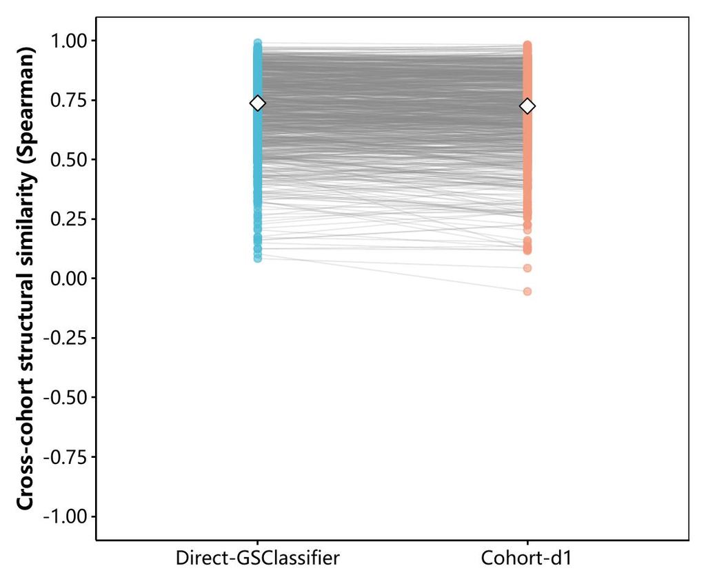

```r
knitr::include_graphics(fig11_jpg)
```

解读：每条线连接同一个队列对在 Direct 与 d1 下的状态距离排序相关，向上表示 d1 更可复现，向下则相反。正向 Direct 平均相似度为 0.713，d1 为 0.701；队列对中有 44.1% 的 d1 数值不低于 Direct。平均配对差为 -0.0124，按共享 cohort 节点重采样的 95% 区间为 -0.0297 至 0.0048。因此总体均值接近零与单条线的上升、下降可以同时成立；区间跨零允许两个方向，未预先规定可接受损失界值前，不能把它写成结构已证明等价或无损。

这里之所以按 cohort 节点重采样，是因为同一队列会出现在许多队列对里。例如 A–B 与 A–C 共同使用 A；把这两条线当作两次完全独立实验，会夸大精度。图上单条线说明具体哪一对发生重排，总体区间回答“换一组队列节点后，平均差可能怎样变化”；二者不能互相替代。

```r
# ==== Figure 12: Direct structural-similarity heatmap (user-adjustable parameters) ====
fig12 <- list(
  # Cohort names are shown once on the rows; columns use the same order.
  width_in = 14,
  height_in = 13,
  base_size = 9,
  tile_line_width = 0.18,
  # Both panels share -1 to 1 so all correlations have a common scale; this supports
  # visible contrast while preserving direct cellwise comparability.
  fill_limits = c(-1, 1),
  fill_midpoint = 0,
  legend_position = "right"
)
p12 <- ggplot2::ggplot(
  structural_direct_heatmap,
  ggplot2::aes(
    x = .data$cohort_a,
    y = .data$cohort_b,
    fill = .data$similarity
  )
) +
  ggplot2::geom_tile(
    color = "white",
    linewidth = fig12$tile_line_width
  ) +
  ggplot2::scale_fill_gradient2(
    low = nature_colors[["blue"]],
    mid = "white",
    high = nature_colors[["red"]],
    midpoint = fig12$fill_midpoint,
    limits = fig12$fill_limits,
    name = "Spearman"
  ) +
  ggplot2::labs(x = "Cohort (row order, top to bottom)", y = "Cohort") +
  ggplot2::coord_fixed() +
  theme_nature_readable(
    base_size = fig12$base_size,
    legend_position = fig12$legend_position
  ) +
  ggplot2::theme(axis.text.x = ggplot2::element_blank(),
    axis.ticks.x = ggplot2::element_blank())

# Readability check: row labels identify both axes because the square matrix
# uses the same cohort order across columns. This avoids overlapping column
# labels while preserving cellwise comparison with Figure 13.
fig12_jpg <- .ae_save_plot(
  p12, "02.03.00. structural-similarity-direct", figure_dir,
  preview_dir, fig12, params$plot_preview_dpi
)
```

```
## Converting page 1 to D:/cache/ccs/_ablation-03/logs/report-previews/02.03.00-structural-reproducibility-20261007185022/02.03.00. structural-similarity-direct.jpg... done!
```

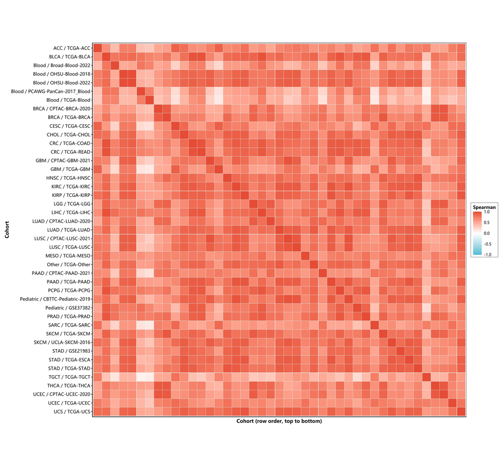

```r
knitr::include_graphics(fig12_jpg)
```

横轴列顺序与左侧队列名从上到下的顺序一致；省略重复的横轴名称，精确队列对可在上方明细表中查询。

解读：这张 Direct 热图为下一张 d1 热图提供同位置、同色阶的基线；每格是一对 cohort 对同一组共有高低状态的距离排序相关。Direct 的平均相似度为 0.713；最高的 Blood/OHSU-Blood-2018 与 Blood/OHSU-Blood-2022 为 0.991，最低的 Blood/PCAWG-PanCan-2017_Blood 与 TGCT/TCGATARGET-TGCT 为 0.084。这说明 Direct 自身已有可跨队列比较的状态关系，同时队列对之间差异很大。颜色不是临床分型标签，也没有给每格单独做显著性检验；比较 d1 时必须回到相同的 cohort 对，而不是比较两张图上最亮的两个不同格子。

```r
# ==== Figure 13: d1 structural-similarity heatmap (user-adjustable parameters) ====
# Reuse the exact Figure 12 dimensions, typography, and color limits so visual
# differences reflect data rather than plotting choices.
fig13 <- fig12
p13 <- ggplot2::ggplot(
  structural_d1_heatmap,
  ggplot2::aes(
    x = .data$cohort_a,
    y = .data$cohort_b,
    fill = .data$similarity
  )
) +
  ggplot2::geom_tile(
    color = "white",
    linewidth = fig13$tile_line_width
  ) +
  ggplot2::scale_fill_gradient2(
    low = nature_colors[["blue"]],
    mid = "white",
    high = nature_colors[["red"]],
    midpoint = fig13$fill_midpoint,
    limits = fig13$fill_limits,
    name = "Spearman"
  ) +
  ggplot2::labs(x = "Cohort (row order, top to bottom)", y = "Cohort") +
  ggplot2::coord_fixed() +
  theme_nature_readable(
    base_size = fig13$base_size,
    legend_position = fig13$legend_position
  ) +
  ggplot2::theme(axis.text.x = ggplot2::element_blank(),
    axis.ticks.x = ggplot2::element_blank())

# Readability check: Figure 13 shares Figure 12's row order, square aspect,
# external legend, and common -1 to 1 scale, enabling cellwise visual
# comparison without rescaling artifacts.
fig13_jpg <- .ae_save_plot(
  p13, "02.03.00. structural-similarity-d1", figure_dir,
  preview_dir, fig13, params$plot_preview_dpi
)
```

```
## Converting page 1 to D:/cache/ccs/_ablation-03/logs/report-previews/02.03.00-structural-reproducibility-20261007185022/02.03.00. structural-similarity-d1.jpg... done!
```

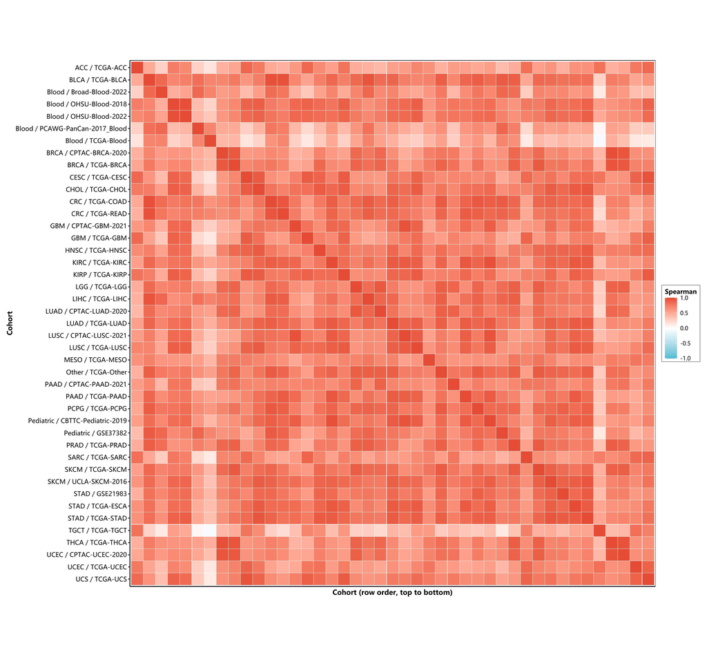

```r
knitr::include_graphics(fig13_jpg)
```

这张图沿用相同的行列顺序；横轴各列仍按左侧队列名从上到下排列。

解读：此图沿用 Direct 热图的格子位置和 −1 至 1 色阶，所以同一个格子的颜色差才对应同一对 cohort 的结构变化。d1 的平均相似度为 0.701，相对 Direct 的平均差为 -0.0124；变化最正向的队列对是 SARC/TCGATARGET-SARC 与 UCS/TCGATARGET-UCS（差 0.208），最负向的是 Blood/TCGATARGET-Blood 与 UCS/TCGATARGET-UCS（差 -0.345）。这些具体格子说明平均值可能遮住方向不同的队列对；挑选极端格子只用于追查共享状态数和来源构成，不可事后当作新发现。这里仅比较五个 gene signature 构成的十种相对状态，总体不确定性仍以共享 cohort 节点的重采样区间判断。

```r
render_dt(
  structural_summary[, c(
    "scope", "cohort_count", "cohort_pair_count",
    "mean_direct_similarity", "median_direct_similarity",
    "mean_d1_similarity", "median_d1_similarity", "mean_delta",
    "median_delta", "fraction_d1_ge_direct", "mean_delta_ci_low",
    "mean_delta_ci_high", "inference_method", "inference_status",
    "min_inference_cohorts", "min_inference_pairs", "p_value_reason"
  )],
  pageLength = 5
)
```

|  | scope | cohort_count | cohort_pair_count | mean_direct_similarity | median_direct_similarity | mean_d1_similarity | median_d1_similarity | mean_delta | median_delta | fraction_d1_ge_direct | mean_delta_ci_low | mean_delta_ci_high | inference_method | inference_status | min_inference_cohorts | min_inference_pairs | p_value_reason |
| --- | --- | --- | --- | --- | --- | --- | --- | --- | --- | --- | --- | --- | --- | --- | --- | --- | --- |
| 1 | all_cohort_pairs | 43 | 903 | 0.713317342134329 | 0.737154150197628 | 0.700913949548934 | 0.724901185770751 | -0.0124033925853946 | -0.00737812911725955 | 0.440753045404208 | -0.0297496541060566 | 0.00477633620899478 | cohort_node_bootstrap | estimable | 4 | 3 | Cohort-pair rows share cohort nodes; a paired Wilcoxon test would treat dependent dyads as independent. |
| 2 | same_cancer_type | 26 | 22 | 0.728889687387711 | 0.783530961791831 | 0.717828482452988 | 0.803359683794466 | -0.0110612049347227 | -0.0108695652173914 | 0.409090909090909 | -0.0515494764579432 | 0.0284963862224732 | cohort_node_bootstrap | estimable | 4 | 3 | Cohort-pair rows share cohort nodes; a paired Wilcoxon test would treat dependent dyads as independent. |

解读：全体队列对混合了同癌种和不同癌种的比较；同癌种子集只保留癌种标签相同、cohort 不同的队列对，以减少“癌种本来不同”对状态排序的影响。当前有效同癌种队列对有 22 对，达到预设推断门槛，平均差为 -0.0111，节点 bootstrap 区间为 [-0.0515, 0.0285]；全体队列对的平均差为 -0.0124。应并排看这两个估计及各自区间：同癌种结果靠近零，只说明这一子集尚未观察到清楚的平均方向，不能推出每个队列对都无损，也不能排除平台、取样和疾病阶段差异。区间按共享 cohort 节点重采样，不把 22 对比较当成同样多次独立实验。

把同癌种分析想成只在同一科目中比较不同学校的成绩：它减少了“科目本来不同”的解释，却没有让学校的设备和学生构成一致。表中的 `cohort_count` 是独立节点数，`cohort_pair_count` 是这些节点组成的比较数；后者更大不代表多出了同样多份独立生物证据。

完整 reference bank 与 external bank 的模块数和组织来源不同，所以还需检查结论是否只由“哪一侧模块更多”造成。Matched-bank 在相同 tissue 组成和相同模块预算下反复抽取 bank，比较每次的平均 $\Delta$；零线仍是 d1 与 Direct 没有观察到平均结构差。它像比较两支人数相同、专业构成相同但成员不同的团队：若换成员后结论常常变号，完整 bank 的单一点估计就很脆弱。这里固定目标数据，重复的是模块设计；散点范围不含新队列抽样的不确定性。

```r
# ==== Figure 14: Reciprocal matched-bank sensitivity (user-adjustable parameters) ====
fig14 <- list(
  # Wide canvas leaves room for two-line direction labels and the external legend.
  width_in = 7.2,
  height_in = 4.8,
  # Base font remains legible in print; jitter exposes all 20 bank repeats.
  base_size = 11,
  point_size = 2.0,
  point_alpha = 0.72,
  jitter_width = 0.10,
  jitter_seed = 20260912L,
  box_width = 0.42,
  full_point_size = 4.0,
  zero_line_width = 0.55,
  legend_position = "bottom"
)
structural_full_direction <- data.frame(
  direction_label = factor(
    c(
      "reference_bank_to_external_targets",
      "external_bank_to_reference_targets"
    ),
    levels = c(
      "reference_bank_to_external_targets",
      "external_bank_to_reference_targets"
    ),
    labels = c(
      "Reference modules\non external targets",
      "External modules\non reference targets"
    )
  ),
  mean_delta = c(
    structural_forward_all$mean_delta,
    structural_reverse_all$mean_delta
  )
)
p14 <- ggplot2::ggplot(
  structural_matched_all,
  ggplot2::aes(x = .data$direction_label, y = .data$mean_delta)
) +
  ggplot2::geom_hline(
    yintercept = 0,
    linewidth = fig14$zero_line_width,
    color = "grey55"
  ) +
  ggplot2::geom_boxplot(
    width = fig14$box_width,
    outlier.shape = NA,
    fill = "grey92",
    color = "grey40"
  ) +
  ggplot2::geom_jitter(
    ggplot2::aes(color = .data$bank_role),
    position = ggplot2::position_jitter(
      width = fig14$jitter_width,
      height = 0,
      seed = fig14$jitter_seed
    ),
    size = fig14$point_size,
    alpha = fig14$point_alpha
  ) +
  ggplot2::geom_point(
    data = structural_full_direction,
    ggplot2::aes(x = .data$direction_label, y = .data$mean_delta),
    inherit.aes = FALSE,
    shape = 23,
    size = fig14$full_point_size,
    fill = "white",
    color = "black",
    stroke = 0.9
  ) +
  ggplot2::scale_color_manual(
    values = c(
      reference = nature_colors[["blue"]],
      external = nature_colors[["orange"]]
    ),
    labels = c(reference = "Reference modules", external = "External modules")
  ) +
  ggplot2::labs(
    x = NULL,
    y = "Mean similarity difference (d1 - Direct)",
    color = "Matched module bank"
  ) +
  theme_nature_readable(
    base_size = fig14$base_size,
    x_text_angle = 0,
    legend_position = fig14$legend_position
  )

# Readability check: two short direction labels prevent clipping, jitter keeps
# all repeats visible, the zero line fixes direction, and outlined diamonds
# distinguish complete-bank estimates from matched design sensitivity.
fig14_jpg <- .ae_save_plot(
  p14, "02.03.00. structural-matched-bank-sensitivity", figure_dir,
  preview_dir, fig14, params$plot_preview_dpi
)
```

```
## Converting page 1 to D:/cache/ccs/_ablation-03/logs/report-previews/02.03.00-structural-reproducibility-20261007185022/02.03.00. structural-matched-bank-sensitivity.jpg... done!
```

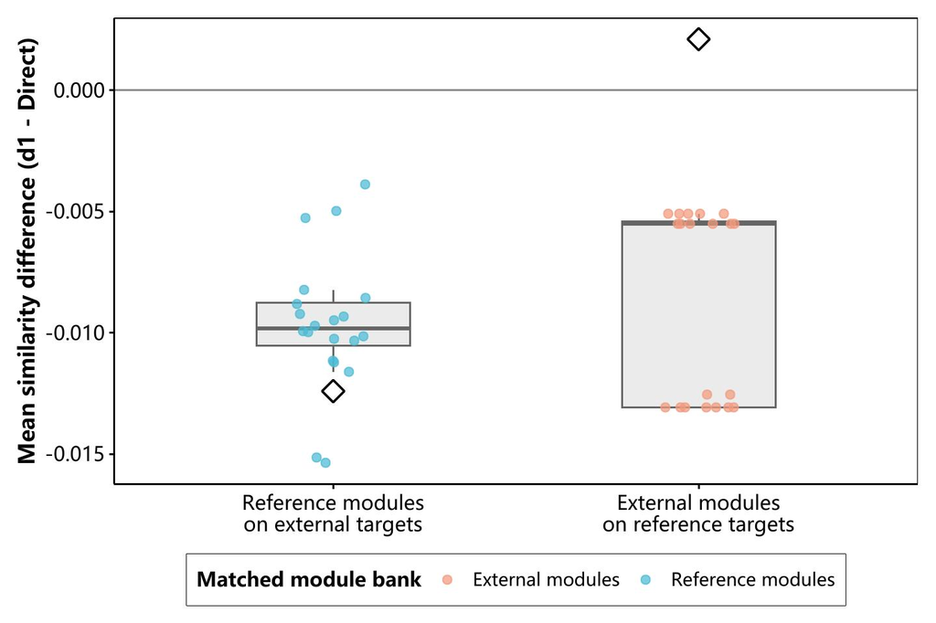

```r
knitr::include_graphics(fig14_jpg)
```

解读：完整正向 bank 有 150 个模块，反向有 43 个，直接比较会把模块预算与来源混在一起。此图固定 tissue 组成，每侧抽取 22 个模块，重复 20 次；散点是每次设计的 d1−Direct 平均结构差，空心菱形是对应完整 bank 的差。正向设计范围为 -0.0154 至 -0.0039，反向为 -0.0131 至 -0.0051。范围越宽，结论越依赖具体选了哪些模块；它固定了目标患者，不能解释成新患者或新队列的置信区间。

```r
render_dt(
  structural_matched_summary[, c(
    "direction", "scope", "repeat_count", "bank_module_count",
    "mean_delta_median", "mean_delta_min", "mean_delta_max",
    "mean_direct_similarity_median", "mean_d1_similarity_median",
    "fraction_d1_ge_direct_median", "range_interpretation"
  )],
  pageLength = 4L
)
```

|  | direction | scope | repeat_count | bank_module_count | mean_delta_median | mean_delta_min | mean_delta_max | mean_direct_similarity_median | mean_d1_similarity_median | fraction_d1_ge_direct_median | range_interpretation |
| --- | --- | --- | --- | --- | --- | --- | --- | --- | --- | --- | --- |
| 1 | external_bank_to_reference_targets | all_cohort_pairs | 20 | 22 | -0.00550406591177461 | -0.0130716162787587 | -0.00508893952698897 | 0.579842719992489 | 0.574338654080715 | 0.49157884369152 | design_sensitivity_not_confidence_interval |
| 2 | external_bank_to_reference_targets | same_cancer_type | 20 | 22 | -0.0120462676950813 | -0.0245358516640951 | -0.0108629947057738 | 0.610418690643017 | 0.598372422947935 | 0.495272727272727 | design_sensitivity_not_confidence_interval |
| 3 | reference_bank_to_external_targets | all_cohort_pairs | 20 | 22 | -0.00981817306387579 | -0.0153543232410775 | -0.0038803461452602 | 0.713317342134329 | 0.703499169070453 | 0.452380952380952 | design_sensitivity_not_confidence_interval |
| 4 | reference_bank_to_external_targets | same_cancer_type | 20 | 22 | -0.00764762246975687 | -0.0227512276919392 | 0.0268714816145646 | 0.728889687387711 | 0.721242064917954 | 0.431818181818182 | design_sensitivity_not_confidence_interval |

解读：在每侧固定 22 个模块并保持 tissue 匹配后，正向重复设计的 d1−Direct 中位效应为 -0.0098，本次设计范围为 -0.0154 至 -0.0039；反向中位效应为 -0.0055，范围为 -0.0131 至 -0.0051。若某一方向的范围横跨零，说明固定目标人群时只换 bank 组成即可改变效应方向；若不跨零，也只说明这批有限设计较稳定。这些最小／最大值不是新患者的置信区间，两方向还换了 target 集合，并共享冻结 Direct 特征合同，不能解释为完全对称的重复实验。

## 5 讨论与分析

### 5.1 本次保留的是哪一层结构

这张地图的精细度有限。可以把它想成比较不同城市中“医院、学校、车站”几类地点之间的布局：布局相似，不要求每位居民住处相同，也不要求每条街的长度相同。当前状态来自预设 gene signature 的相对高低划分，同名高状态不必对应同一个绝对表达分数；Spearman 相似度又只看距离排序。因此本报告没有检验每名患者的精细表达状态、绝对距离或所有生物过程是否保留。

### 5.2 小的正向平均差应怎样理解

完整 bank 的正向平均差为 -0.0124，95% 节点 bootstrap 区间为 [-0.0297, 0.0048]；反向平均差为 0.0021，区间为 [-0.0168, 0.0190]。两方向点估计都靠近零，区间同时容许改善和损失，所以目前较稳妥的判断是：没有确定的平均优势，也尚未排除一定幅度的结构损失。

平均差还会隐藏队列对的得失。正向 d1 不低于 Direct 的队列对占 44.1%，反向占 52.7%；这说明均值不能代表所有比较都得到改善。热图中的极端格子应回到共有状态数、来源和癌种核查，不能仅凭亮色选择支持 d1 的实例。

gene signature 邻居接近度报告出现较一致的负差，而这里的粗结构差靠近零，两者在逻辑上并不矛盾。按粗状态分组后取中心，会弱化一部分组内患者差异；保留下来的组间排序可能相似，患者身边的连续表达邻居却已改变。这与“概率重编码弱化精细排序、保留部分粗结构”的假说相容，但当前两个终点并未直接测量或分解信息尺度，不能把这种解释写成已经确认的机制。

### 5.3 为什么很多队列对仍不等于很多独立实验

正向有 43 个有效 cohort、903 对比较；反向有 143 个 cohort、10153 对比较。一个 cohort 会同时与多个 cohort 比较：若它的状态测量偏移，所有连到它的比较都可能一起变化。这像一个学校参与多场联赛，同一支队伍状态不佳会影响多场成绩，不能把每场比赛都当作完全独立的一支队伍。

因此主区间按共享 cohort 节点重采样，报告末尾的零假设检验也先检查节点结构及模拟覆盖；无法可靠估计的格子保留 NA。队列对数较大不能替代节点数，更不能将普通成对行检验产生的小 P 值当作外部复现证据。

同癌种子集进一步减少“癌种本来不同”的影响。本次正向有 22 对同癌种比较，达到预设推断门槛，平均差为 -0.0111，节点 bootstrap 区间为 [-0.0515, 0.0285]。它只适用于能形成这些队列对的癌种；即便均值靠近零，也不能推出所有癌种均保留结构。平台、疾病阶段和样本构成仍可能不同，同癌种分析没有自动消除这些差异。

### 5.4 双向与 matched-bank 各自解决了什么问题

正向用 reference modules 描述 external targets，反向用 external modules 描述 reference targets，两方向都确保 bank 与 target 患者不重叠。但完整正向 bank 有 150 个模块，反向有 43 个，目标 cohort 数及组成也不同；共同的冻结 Direct 特征合同仍来自原有设计。因此双向检查增加了迁移视角，不能把两个差值直接作差，解释成完全对称的因果实验。

这让完整 bank 的小正向均值更适合被解释为当前配置下的结果，尚不能视为对模块选择不敏感的优势。Matched-bank 控制了模块数与组织组成，却没有让模块训练样本量、特征数和模型质量完全一致；重复设计也共享模块。它的范围及分位数描述有限设计的敏感性，不能冒充新增患者或新增队列的置信区间。

### 5.5 如何把“结构基本保留”变成可以验证的主张

若实际用途允许一定的结构损失，应先规定有科学依据的非劣效界值，并在独立未见 cohort 中估计同一效应。只有区间下界高于负的可接受损失界值，才支持在该用途下损失可接受；若要主张等价，还需区间整体落入预设的双侧等价范围。界值必须在看验证结果前确定，不能围绕当前区间挑选。

另一项验证应更换状态的测量来源，例如使用病理或蛋白测量定义状态，并在同癌种、已知平台组成受控的队列中重复当前结构比较。同时检查重要癌种内状态是否仍可区分；若总体地图相似但关键亚群被合并，泛癌分类用途仍可能受损。这样才能检验跨队列的排序稳定是否具有独立生物意义，而不只反映共享表达数据的稳定性。

目前这项分析的价值是补充 gene signature 邻居接近度所看不到的较大尺度关系，并显示结论对模块组成的敏感性。论文中可报告当前粗状态结构未出现明确平均改善或下降，同时保留区间、同癌种范围和局部表达代价；“新个性化亚型已获验证”仍需要独立目标上的证据。

## 6 数字准确性验证

| 核查 | 当前证据 |
| --- | --- |
| 来源 | 结构结果及表示/输入准备的凭据逐项核验 |
| 外部性 | bank 样本与 target 样本无重叠，见分向 sample audit |
| 独立单位 | cohort 节点而非队列对 |
| 敏感性 | matched-bank 范围保留原有解释，不冒充置信区间 |
| 数字 | 所有内联效应与图表均读取当前 CSV/RDS |

## 7 节点层推断与设计敏感性补充

以下四行分别对应正反方向和全部／同癌种队列对。均值、辅助中位数及 d1 不低于 Direct 的比例都按**共享 cohort 节点**重采样。均值的零假设检验使用删一节点 jackknife 标准误，并先在当前网络上用节点效应及边噪声模拟检查 95% 覆盖；节点稀疏或覆盖未通过的格子保留 NA。有效 P 值在预设四行比较族内采用 Holm 校正。队列对数只是网络边数，不是独立样本数。

```r
render_dt(statistical_inference$structural, pageLength = 4L)
```

|  | direction | scope | mean_delta | mean_ci_low | mean_ci_high | median_delta | median_ci_low | median_ci_high | fraction_d1_ge_direct | fraction_ci_low | fraction_ci_high | p_value | n_cohort | n_pairs | min_node_degree | resamples | valid_resamples | null_simulation_coverage | seed | unit | ci_method | p_method | status | reason | p_value_adj | multiplicity_family |
| --- | --- | --- | --- | --- | --- | --- | --- | --- | --- | --- | --- | --- | --- | --- | --- | --- | --- | --- | --- | --- | --- | --- | --- | --- | --- | --- |
| 1 | reference_bank_to_external_targets | all_cohort_pairs | -0.01240339258539461 | -0.03085940556066551 | 0.004611763259383546 | -0.00737812911725955 | -0.0234519104084321 | 0.00606060606060599 | 0.4407530454042082 | 0.3355989509854321 | 0.5490713785630078 | 0.1662902894813189 | 43 | 903 | 42 | 2000 | 2000 | 0.94 | 20260925 | shared_cohort_node | cohort_node_percentile_bootstrap | node_jackknife_t | estimable |  | 0.6651611579252754 | four_direction_scope_mean_deltas |
| 2 | reference_bank_to_external_targets | same_cancer_type | -0.01106120493472272 | -0.04943642106685574 | 0.02663950040178321 | -0.01086956521739143 | -0.0395256916996047 | 0.0155467720685112 | 0.4090909090909091 | 0.06890804597701149 | 0.772763929618768 |  | 26 | 22 | 1 | 2000 | 2000 |  | 20260926 | shared_cohort_node | cohort_node_percentile_bootstrap | not_estimable | not_estimable | sparse_node_network_or_low_valid_bootstrap_rate |  | four_direction_scope_mean_deltas |
| 3 | external_bank_to_reference_targets | all_cohort_pairs | 0.00210504113278812 | -0.01623258156348999 | 0.01951338895258066 | 0.00566534914360994 | -0.00777338603425559 | 0.0183135704874835 | 0.5266423717127943 | 0.465065388565782 | 0.5872852922902181 | 0.8143724500511822 | 143 | 10153 | 142 | 2000 | 2000 | 0.9433333333333334 | 20260927 | shared_cohort_node | cohort_node_percentile_bootstrap | node_jackknife_t | estimable |  | 1 | four_direction_scope_mean_deltas |
| 4 | external_bank_to_reference_targets | same_cancer_type | -0.003476518205787827 | -0.03476565319982588 | 0.02648357913036687 | 0.0104084321475626 | -0.007776679841897255 | 0.0283267457180502 | 0.5476363636363636 | 0.4581004771042091 | 0.6393158935900959 |  | 137 | 1375 | 1 | 2000 | 2000 |  | 20260928 | shared_cohort_node | cohort_node_percentile_bootstrap | not_estimable | not_estimable | sparse_node_network_or_low_valid_bootstrap_rate |  | four_direction_scope_mean_deltas |

Matched-bank 的 2.5%—97.5% 分位范围只描述当前患者及冻结模块池下，20 次组成设计的分布中心。重复设计共享模块，故此处不报告人口层 P 值，也不把分位范围写成新 cohort 的 95% 置信区间。

```r
render_dt(statistical_inference$matched_bank, pageLength = 4L)
```

|  | direction | scope | design_median | design_q025 | design_q975 | n_design | unit | method | condition | p_value | reason |
| --- | --- | --- | --- | --- | --- | --- | --- | --- | --- | --- | --- |
| external_bank_to_reference_targets.all_cohort_pairs | external_bank_to_reference_targets | all_cohort_pairs | -0.00550406591177461 | -0.0130716162787587 | -0.00508893952698897 | 20 | matched_bank_design_repeat | empirical_design_distribution | frozen_patients_and_module_pool |  | overlapping_modules_are_not_independent_new_cohorts |
| reference_bank_to_external_targets.all_cohort_pairs | reference_bank_to_external_targets | all_cohort_pairs | -0.009818173063875796 | -0.01525071238165272 | -0.004400271675296955 | 20 | matched_bank_design_repeat | empirical_design_distribution | frozen_patients_and_module_pool |  | overlapping_modules_are_not_independent_new_cohorts |
| external_bank_to_reference_targets.same_cancer_type | external_bank_to_reference_targets | same_cancer_type | -0.0120462676950813 | -0.0245358516640951 | -0.0108629947057738 | 20 | matched_bank_design_repeat | empirical_design_distribution | frozen_patients_and_module_pool |  | overlapping_modules_are_not_independent_new_cohorts |
| reference_bank_to_external_targets.same_cancer_type | reference_bank_to_external_targets | same_cancer_type | -0.00764762246975687 | -0.02000613845969579 | 0.02364564618517184 | 20 | matched_bank_design_repeat | empirical_design_distribution | frozen_patients_and_module_pool |  | overlapping_modules_are_not_independent_new_cohorts |